# pavo

## Setting Scales and Defining Objects

The functionality of `procimg()` is currently centred on rotating and resizing images, setting a real-world image scale, and/or distinguishing the focal object from its background. Rotating an image simply requires inputting an angle, in degrees, by which the image is rotated about its centre, while resizing requires a scaling factor by which the size of image(s) are to be decreased or increased. Setting scales and distinguishing backgrounds, in contrast, are both interactive procedures, meaning that we are presented with the focal image and must select points on it using the mouse (either a line, when setting a scale, or a polygon when identifying the focus). If setting a scale, we specify a scale in our preferred units via `scaledist`, and then click the endpoints of the scale within the image (which could be a ‘formal’ scale, or simply the length of a wing or another known reference object). This information, as usual, is attached to the image as an attribute.

```r
# Interactively specify the real-world scale of the image. Here 100 mm.
butterflies <- procimg(butterflies, scaledist = 100)
```

```r
# Interactively specify a smoothed polygon around the focal objects
butterflies <- procimg(butterflies, outline = TRUE, iterations = 1)
```

All of these options can be simultaneously specified in a single call to `procimg()`, and the `pavo 2.0` publication offers a useful example of such processing, since the more involved features are difficult illustrate to here due to their interactive nature.

## Image Colour-Classification

The segmentation of RGB images into discrete colour-classes is an essential step on the road to several analyses, and this is carried out in `pavo` via `classify()`. The function currently implements k-means clustering which, although an ‘unsupervised’ methods of image segmentation, offers some flexibility in the way in which it is carried out. In the simplest case, we can specify an image or image(s) as well as the number of discrete colours in each (an important step to be closely considered beforehand beforehand, often through visual modelling to estimate the number of discriminable colours), and allow the k-means clustering algorithm to do its work. Since we have two images, with (arguably) four and three colours each, including the white background, we can specify this information using `kcols`, before visualising the results with `summary`. The `summary` function, with `plot = TRUE`, is also particularly useful for understanding the colour-class labels, or ID’s, assigned to each colour, as well as visualising the accuracy of the classification process, which may be enhanced by specifying strongly-contrasting ‘false’ colours for plotting through the `col` argument.

```r
butterflies_class <- classify(butterflies, kcols = c(4, 3))
```

```
## Image classification in progress...
```

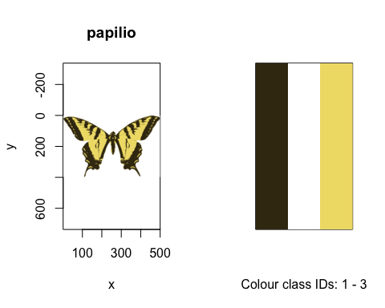

```r
# Note that we could simply feed the list of images to summary, rather than
# specifying individual images, and they would progress automatically
# with user input.

summary(butterflies_class[[2]], plot = TRUE)
```

There are other options available, which may be of particular use when the classification process is not producing the results that might be expected *a priori*. If analysing similar images with homologous colour patterns (e.g. individuals within a species), we could specify a single ‘reference’ image in a list to be initially classified, using `refID`, with the RGB centres identified in this reference image used as pre-specified cluster centres in subsequent images. This helps to ensure that homologous pattern elements are reliably identified and classified between images. The `classify()` function also offers an interactive option, via `interactive = TRUE`, wherein we can interactively click on representative colours within an image (or images individually), with the RGB values then used as cluster centres. This is particularly useful when images are being erroneously classified, since the standard k-means process randomly selects initial centres and so may (by chance) miss smaller patches, or confuse similar colours. By specifying the initial RGB centres interactively, it can be easier for the process to distinguish or ‘pull apart’ colours in such circumstances. Ultimately, there are several combinations of options available during classification, which are also documented in the help file. For our butterflies, for example, we could use any of the following (though some would be very ill-advised):

```r
# Automatic classification.
butterflies_class <- classify(butterflies, kcols = c(4, 3))
```

```
## Image classification in progress...
```

```r
# Automatic classification using a reference image, identified by name.
butterflies_class <- classify(butterflies, refID = 'h_melpomene', kcols = 3)
```

```
## Image classification in progress...
```

```r
# Classification using interactively-specified centres for each image, with no
# need to specify kcols (since it will be inferred from the numbers of colours selected)
butterflies_class <- classify(butterflies, interactive = TRUE)

# Classification using interactively-specified centres for the single reference image
# (here, the first in the list). We could also specify reference image using it's name,
# as above.
butterflies_class <- classify(butterflies, refID = 1, interactive = TRUE)
```

# Analyzing Image Data

## Adjacency and Boundary Strength Analyses, and Overall Pattern Contrasts

The adjacency ([12]) and boundary strength ([13]) analyses offer a powerful method for quantifying various features of colour pattern geometry. Briefly, the process entails classifying the pixels of images into a number of discrete colour classes, using `classify()` as described above, before sampling the now-classified image with an evenly spaced grid of user-specified density. The column-wise and row-wise colour-class transitions between adjacent points are then tallied, and from this a suite of summary statistics on pattern structure — from simple colour proportions, through to colour diversity and pattern complexity — are estimated. If the colour ‘distance’ between adjacent colour classes is known, such as might be estimated using spectral data for receptor-noise modelling via `vismodel()` and `coldist()`, then this can also be incorporated to derive several measures of the salience of patch boundaries ([13]). Finally, if estimates of hue, saturation, and/or brightness are known for each discrete colour in a pattern, then these can be included through the `hsl` argument for general, area-weighted measures of overall pattern contrast ([14]).

In `pavo`, this is all carried out through the `adjacent()` function, which takes several arguments that should be well understood. For our butterflies, we’ll specify a full x-dimension scale of 200 mm using `xscale` (which could be ignored if we specify scales using `procimg()`), and a sampling density of 200, for a 200 x 200 grid. Since the white background of our images is fake and of no interest, we will also exclude it by specifying the colour-class ID that corresponds to it (for more complex backgrounds, we could instead use `procimg()`, as above, and ignore this argument).

```r
butterflies_adj <- adjacent(butterflies_class, xscale = 200, xpts = 200, bkgID = 1)
head(butterflies_adj)
```

```
##             k     N n_off       p_1        p_2       p_3     q_1_1
## h_melpomene 3 54064  4106 0.5833824 0.06496324 0.3516544 0.5649600
## papilio     3 63241  4387 0.5607233 0.20022013 0.2390566 0.5483942
##                   q_1_2      q_2_2      q_1_3      q_2_3     q_3_3
## h_melpomene 0.010728026 0.03786253 0.02093815 0.04428085 0.3212304
## papilio     0.007163075 0.17305229 0.01283977 0.04936671 0.2091839
##                 t_1_2     t_1_3     t_2_3          m        m_r        m_c
## h_melpomene 0.1412567 0.2756941 0.5830492 0.07547794 0.06933824 0.08161765
## papilio     0.1032596 0.1850923 0.7116481 0.06894056 0.07836478 0.05951633
##                     A       Sc       St        Jc        Jt         B
## h_melpomene 0.8495495 2.135766 2.294067 0.7119221 0.7646890 0.7433025
## papilio     1.3166937 2.429267 1.813682 0.8097558 0.6045606 0.8527468
##                    Rt Rab m_dS s_dS cv_dS m_dL s_dL cv_dL m_hue s_hue
## h_melpomene 0.4359071   1   NA   NA    NA   NA   NA    NA    NA    NA
## papilio     0.5513647   1   NA   NA    NA   NA   NA    NA    NA    NA
##             var_hue m_sat s_sat cv_sat m_lum s_lum cv_lum
## h_melpomene      NA    NA    NA     NA    NA    NA     NA
## papilio          NA    NA    NA     NA    NA    NA     NA
```

The output is a suite of statistics describing colour pattern structure and geometry in a tidy data frame that, since we fed it a list of images, contains one row for each of our samples. As always, the function’s help file (`?adjacent`) summarises the meaning of each output variable, and the original references listed therein contain the full discussion. Note that some of the output is `NA`, which might occur when the focal statistic simply makes no sense for the image in question (such as the transition frequency between colour categories 3 and 4, for an image that contains only 3 colour categories). Others may result when we do not give `adjacent()` enough information, such as the colour-distances required to calculate the boundary-strength statistics, or the colourmetrics required for overall pattern contrast. If we do give the function this information, we can see that those final variables now contain sensible output.

```r
# Create a fake matrix of pairwise colour- and luminance distances between all
# colour patten elements, as might be attained through visual modelling of spectral data.
distances <- data.frame(c1 = c(1, 1, 2),
                        c2 = c(2, 3, 3),
                        dS = c(10.6, 5.1, 4.4),
                        dL = c(1.1, 2.5, 3.2))

# Take a look
distances
```

```
##   c1 c2   dS  dL
## 1  1  2 10.6 1.1
## 2  1  3  5.1 2.5
## 3  2  3  4.4 3.2
```

```r
# And our fake hue angles (in radians), saturation, and luminance values, for each
# colour pattern element
hsl_vals <- data.frame(patch = 1:3,
                       hue = c(1.2, 2.2, 1.6),
                       lum = c(10, 5, 7),
                       sat = c(3.5, 1.1, 6.3))

# Take a look
hsl_vals
```

```
##   patch hue lum sat
## 1     1 1.2  10 3.5
## 2     2 2.2   5 1.1
## 3     3 1.6   7 6.3
```

```r
# Now feed this information into the adjacency analysis using the less-colourful
# of our two images, for convenience (though this could be readily extended to
# include a list of images along with a list of distances and hsl values)
adjacent(butterflies_class[[2]], xscale = 200, xpts = 200, bkgID = 1, coldists = distances, hsl = hsl_vals)
```

```
## Using single set of coldists for all images.
```

```
## Using single set of hsl values for all images.
```

```
##         k     N n_off       p_1       p_2       p_3     q_1_1       q_1_2
## papilio 3 63241  4387 0.5607233 0.2002201 0.2390566 0.5483942 0.007163075
##             q_2_2      q_1_3      q_2_3     q_3_3     t_1_2     t_1_3
## papilio 0.1730523 0.01283977 0.04936671 0.2091839 0.1032596 0.1850923
##             t_2_3          m        m_r        m_c        A       Sc
## papilio 0.7116481 0.06894056 0.07836478 0.05951633 1.316694 2.429267
##               St        Jc        Jt         B        Rt Rab     m_dS
## papilio 1.813682 0.8097558 0.6045606 0.8527468 0.5513647   1 5.169774
##             s_dS     cv_dS    m_dL      s_dL     cv_dL    m_hue     s_hue
## papilio 2.780084 0.5377573 2.85359 0.9745272 0.3415092 1.663715 0.4154308
##           var_hue   m_sat    s_sat    cv_sat   m_lum   s_lum  cv_lum
## papilio 0.0826731 3.68883 2.255009 0.6113073 8.28173 2.67326 0.32279
```

# Classes and Attributes

To enable the comprehensive workflow of `pavo`, we’ve implemented an expanded class system. Spectra will be of class `rspec` as long as we use one of `pavo`’s spectral import or processing functions, or explicitly convert an object using `as.rspec()`. Similarly, images will be of class `rimg` when imported via `getimg()`, or if converted using `as.rimg()`. The results of `vismodel()` are objects of class `vismodel` and the results of `colspace()` are, unsurprisingly, objects of class `colspace`. Most of these classes inherit from `data.frame`, and contain a suite of attributes that describe the object’s characteristics (e.g. options used in visual modelling such as the selected visual system and illuminant, and properties of the modelled colourspace). These are easily viewed using the `summary` function (on any `rspec`, `rimg`, `vismodel`, or `colspace` object), which will return the attributes and summary data (where appropriate) in a readable format.

# Final Thoughts

We hope to have demonstrated the flexibility of `pavo` when it comes to importing, processing, exploring, visualizing and analysing spectral and spatial data. Our aim was to provide a cohesive, start-to-finish workflow of colour pattern analysis with `R`, without the need for additional software. Though our examples have broadly focused on bird reflectance data and visual models, `pavo` should be easily extended to any taxon of interest, including the possibility of modelling sensitivity curves through the `sensmodel()` function.

For suggestions, assistance and/or bug reports, we suggest getting in touch via ‘gitter’ at https://gitter.im/r-pavo/help, which is essentially a public chat room for all things pavo. If you have a bug to report, we’d appreciate it if you could also include a reproducible example when possible. Users familiar with git may prefer to open an issue on the project’s [github page](https://github.com/rmaia/pavo), or to make a pull-request directly.

# Citation of methods implemented in `pavo`

# Acknowledgments

We would like to thank Matthew D. Shawkey and Stephanie M. Doucet for insights and support, and Jarrod D. Hadfield and Mary Caswell Stoddard for sharing code that helped us develop some of `pavo`’s capabilities.

# References

1. Cuthill IC, Bennett ATD, Partridge JC, Maier EJ. 1999 Plumage reflectance and the objective assessment of avian sexual dichromatism. *The American Naturalist* **153**, 183–200. (doi:10.1086/303160)

2. Vorobyev M, Osorio DC, Bennett ATD, Marshall NJ, Cuthill IC. 1998 Tetrachromacy, oil droplets and bird plumage colours. *J Comp Physiol A* **183**, 621–633. (doi:10.1007/s003590050286)

3. Endler JA. 1990 On the measurement and classification of colour in studies of animal colour patterns. *Biological Journal of the Linnean Society* **41**, 315–352. (doi:10.1111/j.1095-8312.1990.tb00839.x)

4. Chittka L. 1992 The colour hexagon: A chromaticity diagram based on photoreceptor excitations as a generalized representation of colour opponency. *J Comp Physiol A* **170**, 533–543. (doi:10.1007/BF00199331)

5. Backhaus W. 1991 Color opponent coding in the visual system of the honeybee. *Vision Research* **31**, 1381–1397. (doi:10.1016/0042-6989(91)90059-E)

6. Montgomerie R. 2006 Analyzing Colors. In *Bird Coloration, Volume 1: Mechanisms and Measurements* (eds GE Hill, KJ McGraw), p. 640. Harvard University Press.

7. Goldsmith TH. 1990 Optimization, Constraint, and History in the Evolution of Eyes. *The Quarterly Review of Biology* **65**, 281–322. (doi:10.1086/416840)

8. Stoddard MC, Prum RO. 2008 Evolution of avian plumage color in a tetrahedral color space: A phylogenetic analysis of New World buntings. *The American Naturalist* **171**, 755–776. (doi:10.1086/587526)

9. Govardovskii VI, Fyhrquist N, Reuter T, Kuzmin DG, Donner K. 2000 In search of the visual pigment template. *Visual Neuroscience* **17**, 509–528.

10. Hart NS, Vorobyev M. 2005 Modelling oil droplet absorption spectra and spectral sensitivities of bird cone photoreceptors. *J Comp Physiol A* **191**, 381–392. (doi:10.1007/s00359-004-0595-3)

11. Stoddard MC, Stevens M. 2011 Avian vision and the evolution of egg color mimicry in the common cuckoo. *Evolution* **65**, 2004–2013. (doi:10.1111/j.1558-5646.2011.01262.x)

12. Endler JA. 2012 A framework for analysing colour pattern geometry: Adjacent colours. *Biol J Linn Soc* **107**, 233–253. (doi:10.1111/j.1095-8312.2012.01937.x)

13. Endler JA, Cole GL, Kranz AM. 2018 Boundary strength analysis: Combining colour pattern geometry and coloured patch visual properties for use in predicting behaviour and fitness. *Methods in Ecology and Evolution* (doi:10.1111/2041-210X.13073)

14. Endler JA, Mielke PW. 2005 Comparing entire colour patterns as birds see them. *Biol J Linn Soc* **86**, 405–431. (doi:10.1111/j.1095-8312.2005.00540.x)